# FigureYa204PCAscore

**Author(s)**: Xiaofan Lu  
**Reviewers**: Ying Ge, Hui Huang  
**Date**: 2025-11-30

## 1 Academic Citation

If you use this code in your work or research, we kindly request that you cite our publication:

Xiaofan Lu, et al. (2025). FigureYa: A Standardized Visualization Framework for Enhancing Biomedical Data Interpretation and Research Efficiency. iMetaMed. https://doi.org/10.1002/imm3.70005

## 2 需求描述 Requirement Description

想实现下这个文章的建模方法，不同于常规的lasso, cox回归系数与基因表达量的乘积，这篇文章采用Boruta降维，联合主成分分析第一主成分构建 signature score，特别适合做分子分型分析。

I want to try the modeling method of this article, which is different from the conventional lasso, the product of the cox regression coefficient and the gene expression, this article uses Boruta to reduce the dimension and combine the principal component analysis with the first principal component to construct a signature score, which is especially suitable for molecular typing analysis.

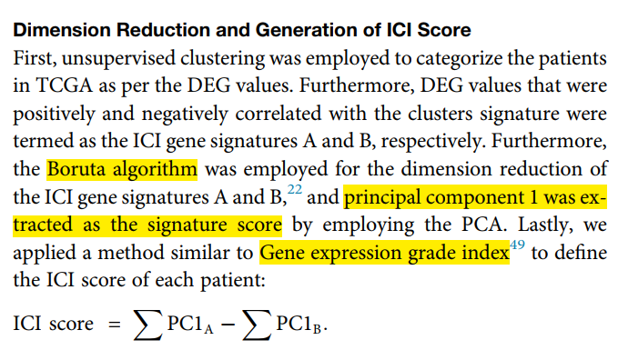

From https://www.cell.com/molecular-therapy-family/nucleic-acids/fulltext/S2162-2531(20)30259-6

## 3 应用场景 Application Scenarios

根据Figure201ClusterCorrelation得到的亚型以及ICI signature结果，进一步利用Boruta算法对AB签名降维，并利用PCA计算单样本ICI得分。

According to the isoforms obtained by Figure201ClusterCorrelation and the ICI signature results, the Boruta algorithm was used to reduce the dimensionality of AB signatures, and the single-sample ICI score was calculated by PCA.

用于分子分型，用 PC1 将样本分为高/低两组，后面可以再验证两组的生存、免疫特征差异。

Used for molecular typing, using PC1 to divide samples into high/low groups, and then verify the survival and immune characteristics of the two groups.

## 4 环境设置 Environment settings

```r
source("install_dependencies.R")
```

```
## Starting R package installation...
## ===========================================
##
## Installing CRAN packages...
## Package already installed: Boruta
## Package already installed: ggplot2
## Package already installed: ggpubr
## Package already installed: pheatmap
##
## ===========================================
## Package installation completed!
## You can now run your R scripts in this directory.
```

```r
library(Boruta) # Boruta降维 # Boruta dimensionality reduction
library(ggplot2) # 画图 # Plotting
library(ggpubr) # 画图增强 # Plotting enhancement
library(pheatmap) # 热图 # Heatmap
Sys.setenv(LANGUAGE = "en") #显示英文报错信息 # Display English error messages
options(stringsAsFactors = FALSE) #禁止chr转成factor # Prohibit converting chr to factor
```

## 5 输入文件 Input Files

easy_input_expr.txt，表达矩阵，这里与原文保持一致，用了TPM，也可以用FPKM。FigureYa201ClusterCorrelation的输入文件是FPKM，同样也可以用TPM。

easy_input_cluster.txt，把Figure201ClusterCorrelation获得的亚型信息（ConsensusCluster文件夹里，ConsensusCluster.k=X.consensusClass.csv对应每种分类数量下sample所在的cluster）写在cluster列。其余为样本信息，跟FigureYa201ClusterCorrelation的`easy_input_sinfo.txt`文件一致。

ouput_ICIsignatureGene.txt，Figure201ClusterCorrelation的ICI signature gene结果。

easy_input_expr.txt, the expression matrix, which is consistent with the original text, uses TPM, and FPKM can also be used. The input file of FigureYa201ClusterCorrelation is FPKM, and TPM can also be used.

easy_input_cluster.txt, write the subtype information obtained by Figure201ClusterCorrelation (in the ConsensusCluster folder, ConsensusCluster.k=X.consensusClass.csv the cluster corresponding to the number of samples under each category) in the cluster column. The rest is sample information, which is the same as the ‘easy_input_sinfo.txt’ file of FigureYa201ClusterCorrelation.

ouput_ICIsignatureGene.txt, ICI signature gene results of Figure201ClusterCorrelation.

```r
# 加载表达谱 # Load the expression spectrum
expr <- read.table("easy_input_expr.txt",sep = "\t",row.names = 1,check.names = F,stringsAsFactors = F,header = T)
tumsam <- colnames(expr)[substr(colnames(expr),11,12) == "01"]
expr <- expr[,tumsam]
indata <- t(scale(t(log2(expr + 1)))) # z-score表达谱 # z-score expression spectrum

# 加载亚型结果 # Load subtype results
annCol <- read.table("easy_input_cluster.txt",sep = "\t",row.names = 1,check.names = F,stringsAsFactors = F,header = T)
table(annCol$`Gene cluster`)
```

```
##
##   A   B   C
## 173 166 141
```

```r
# 加载Figure201ClusterCorrelation的ICI signature gene结果
# Load the ICI signature gene result of Figure201ClusterCorrelation
outTab <- read.table("ouput_ICIsignatureGene.txt",sep = "\t",row.names = NULL,header = T,stringsAsFactors = F,check.names = F)
table(outTab$direct) # AB两种签名按相关性正负来分类，正相关标为A，否则标为B # The two types of signatures are classified according to the positive and negative correlations, and the positive correlation is marked as A, otherwise it is marked as B
```

```
##
##   A   B
## 938 131
```

## 6 用Boruta对ICI signature降维 Use Boruta to reduce the dimensionality of the ICI signature

这一步原则上是应该把AB两种签名一起来构建预后签名的。但这套数据情况特殊，因此遇到了问题（负相关结果被淹没），因此我们拆开A、B签名，分开降维。

In principle, this step should combine the two signatures of AB to construct the prognostic signature. However, this set of data is a special case, so we have encountered a problem (the negative correlation results are drowned out), so we take apart the A and B signatures and reduce the dimensionality separately.

### 6.1 原则上：一起构建预后签名 In principle: build prognostic signatures together

```r
set.seed(20201024)
dat.boruta <- as.data.frame(t(indata[outTab$gene,rownames(annCol)]))
borutafit <- Boruta(x = as.matrix(dat.boruta),
                    y = as.factor(annCol$`Gene cluster`), # multiclassification
                    doTrace = 2,
                    maxRuns = 100,
                    ntree = 500)
```

```
##  1. run of importance source...
```

```
##  2. run of importance source...
```

```
##  3. run of importance source...
```

```
##  4. run of importance source...
```

```
##  5. run of importance source...
```

```
##  6. run of importance source...
```

```
##  7. run of importance source...
```

```
##  8. run of importance source...
```

```
##  9. run of importance source...
```

```
##  10. run of importance source...
```

```
##  11. run of importance source...
```

```
##  12. run of importance source...
```

```
##  13. run of importance source...
```

```
##  14. run of importance source...
```

```
##  15. run of importance source...
```

```
##  16. run of importance source...
```

```
##  17. run of importance source...
```

```
## After 17 iterations, +23 secs:
```

```
##  confirmed 87 attributes: ABCB4, ACACB, ACTN2, ANGPTL1, ANK2 and 82 more;
```

```
##  rejected 411 attributes: ABCA12, ABCA8, ABCA9, ADH1B, AHNAK2 and 406 more;
```

```
##  still have 571 attributes left.
```

```
##  18. run of importance source...
```

```
##  19. run of importance source...
```

```
##  20. run of importance source...
```

```
##  21. run of importance source...
```

```
##  22. run of importance source...
```

```
## After 22 iterations, +27 secs:
```

```
##  confirmed 29 attributes: ACTC1, ARHGAP4, CA3, CD28, CD84 and 24 more;
```

```
##  rejected 71 attributes: ACY3, APOE, BATF, BHLHE22, CAMK4 and 66 more;
```

```
##  still have 471 attributes left.
```

```
##  23. run of importance source...
```

```
##  24. run of importance source...
```

```
##  25. run of importance source...
```

```
##  26. run of importance source...
```

```
## After 26 iterations, +31 secs:
```

```
##  confirmed 12 attributes: ACTA1, ATP8A1, CYTH4, FLI1, HVCN1 and 7 more;
```

```
##  rejected 64 attributes: ACKR1, AFF3, APOL4, C1QA, CD1C and 59 more;
```

```
##  still have 395 attributes left.
```

```
##  27. run of importance source...
```

```
##  28. run of importance source...
```

```
##  29. run of importance source...
```

```
## After 29 iterations, +33 secs:
```

```
##  confirmed 7 attributes: CD3E, CDO1, FGR, PLEKHO1, SLAMF6 and 2 more;
```

```
##  rejected 21 attributes: ABCA3, AOX1, BTNL9, CAPN6, CD69 and 16 more;
```

```
##  still have 367 attributes left.
```

```
##  30. run of importance source...
```

```
##  31. run of importance source...
```

```
##  32. run of importance source...
```

```
##  33. run of importance source...
```

```
## After 33 iterations, +36 secs:
```

```
##  confirmed 10 attributes: AKNA, ANKRD44, CYP27A1, GAB3, ITK and 5 more;
```

```
##  rejected 16 attributes: APOC2, BTN3A2, C7, CCR7, CD3D and 11 more;
```

```
##  still have 341 attributes left.
```

```
##  34. run of importance source...
```

```
##  35. run of importance source...
```

```
##  36. run of importance source...
```

```
## After 36 iterations, +39 secs:
```

```
##  confirmed 14 attributes: ABI3, ABI3BP, CCDC170, CD180, CD3G and 9 more;
```

```
##  rejected 11 attributes: ALOX5AP, ALPK2, CD200R1, CD86, COLEC12 and 6 more;
```

```
##  still have 316 attributes left.
```

```
##  37. run of importance source...
```

```
##  38. run of importance source...
```

```
##  39. run of importance source...
```

```
## After 39 iterations, +41 secs:
```

```
##  confirmed 11 attributes: CD96, CSF1R, HAVCR2, ITM2A, LAT2 and 6 more;
```

```
##  rejected 7 attributes: ICAM3, IL18RAP, PILRA, SELP, SIRPG and 2 more;
```

```
##  still have 298 attributes left.
```

```
##  40. run of importance source...
```

```
##  41. run of importance source...
```

```
##  42. run of importance source...
```

```
## After 42 iterations, +43 secs:
```

```
##  confirmed 10 attributes: CCRL2, CILP, CLEC2D, IL18BP, LILRB2 and 5 more;
```

```
##  rejected 4 attributes: CD163, CD74, N4BP2L1, SIRPB1;
```

```
##  still have 284 attributes left.
```

```
##  43. run of importance source...
```

```
##  44. run of importance source...
```

```
##  45. run of importance source...
```

```
## After 45 iterations, +45 secs:
```

```
##  confirmed 2 attributes: MAP4K1, PIK3R5;
```

```
##  rejected 5 attributes: GFRA2, SLAMF8, TMEM150B, TMEM178B, ZNF521;
```

```
##  still have 277 attributes left.
```

```
##  46. run of importance source...
```

```
##  47. run of importance source...
```

```
##  48. run of importance source...
```

```
## After 48 iterations, +47 secs:
```

```
##  confirmed 2 attributes: CD2, ELMO1;
```

```
##  rejected 4 attributes: ARHGAP25, ATP2A3, PSTPIP1, TOX;
```

```
##  still have 271 attributes left.
```

```
##  49. run of importance source...
```

```
##  50. run of importance source...
```

```
##  51. run of importance source...
```

```
## After 51 iterations, +50 secs:
```

```
##  confirmed 1 attribute: SMPX;
```

```
##  rejected 8 attributes: BCL2A1, GABRP, GPR183, PDE6B, PRG4 and 3 more;
```

```
##  still have 262 attributes left.
```

```
##  52. run of importance source...
```

```
##  53. run of importance source...
```

```
##  54. run of importance source...
```

```
## After 54 iterations, +52 secs:
```

```
##  confirmed 4 attributes: DDIT4L, ST8SIA4, TBXAS1, TESC;
```

```
##  rejected 4 attributes: CD52, CXCR3, LILRA2, THEMIS;
```

```
##  still have 254 attributes left.
```

```
##  55. run of importance source...
```

```
##  56. run of importance source...
```

```
##  57. run of importance source...
```

```
## After 57 iterations, +54 secs:
```

```
##  rejected 4 attributes: FCGR1B, GJB2, NLRP3, SLAIN1;
```

```
##  still have 250 attributes left.
```

```
##  58. run of importance source...
```

```
##  59. run of importance source...
```

```
##  60. run of importance source...
```

```
## After 60 iterations, +56 secs:
```

```
##  rejected 4 attributes: EIF4E3, KRT17, TMEM119, ZNF423;
```

```
##  still have 246 attributes left.
```

```
##  61. run of importance source...
```

```
##  62. run of importance source...
```

```
## After 62 iterations, +58 secs:
```

```
##  confirmed 2 attributes: CXCL12, FPR3;
```

```
##  rejected 4 attributes: FGD3, HLA.DRA, IL12RB1, IRF4;
```

```
##  still have 240 attributes left.
```

```
##  63. run of importance source...
```

```
##  64. run of importance source...
```

```
##  65. run of importance source...
```

```
## After 65 iterations, +60 secs:
```

```
##  confirmed 1 attribute: CNRIP1;
```

```
##  rejected 4 attributes: ADRA2A, EPYC, MS4A4A, PAQR8;
```

```
##  still have 235 attributes left.
```

```
##  66. run of importance source...
```

```
##  67. run of importance source...
```

```
##  68. run of importance source...
```

```
## After 68 iterations, +1 mins:
```

```
##  confirmed 2 attributes: LPXN, TNFRSF14;
```

```
##  rejected 4 attributes: APOL3, CD8B, DOCK10, TLR1;
```

```
##  still have 229 attributes left.
```

```
##  69. run of importance source...
```

```
##  70. run of importance source...
```

```
##  71. run of importance source...
```

```
## After 71 iterations, +1.1 mins:
```

```
##  confirmed 3 attributes: JAM2, NCF4, NLRC4;
```

```
##  rejected 4 attributes: FAM49A, IGSF6, PDK4, PPM1K;
```

```
##  still have 222 attributes left.
```

```
##  72. run of importance source...
```

```
##  73. run of importance source...
```

```
## After 73 iterations, +1.1 mins:
```

```
##  confirmed 3 attributes: ADAMDEC1, FXYD6, SAMSN1;
```

```
##  rejected 4 attributes: IL4I1, ITGB7, PRF1, SFMBT2;
```

```
##  still have 215 attributes left.
```

```
##  74. run of importance source...
```

```
##  75. run of importance source...
```

```
##  76. run of importance source...
```

```
## After 76 iterations, +1.1 mins:
```

```
##  confirmed 4 attributes: FDCSP, GNG2, PDE4B, TNFAIP8L2;
```

```
##  rejected 4 attributes: ABCA6, ICOS, LTB, PPM1M;
```

```
##  still have 207 attributes left.
```

```
##  77. run of importance source...
```

```
##  78. run of importance source...
```

```
##  79. run of importance source...
```

```
## After 79 iterations, +1.2 mins:
```

```
##  confirmed 1 attribute: CSRP3;
```

```
##  rejected 4 attributes: CD33, PTPN7, SIGLEC10, STAB1;
```

```
##  still have 202 attributes left.
```

```
##  80. run of importance source...
```

```
##  81. run of importance source...
```

```
## After 81 iterations, +1.2 mins:
```

```
##  confirmed 1 attribute: MEOX2;
```

```
##  rejected 1 attribute: FCRL2;
```

```
##  still have 200 attributes left.
```

```
##  82. run of importance source...
```

```
##  83. run of importance source...
```

```
##  84. run of importance source...
```

```
## After 84 iterations, +1.2 mins:
```

```
##  rejected 1 attribute: CD79B;
```

```
##  still have 199 attributes left.
```

```
##  85. run of importance source...
```

```
##  86. run of importance source...
```

```
##  87. run of importance source...
```

```
## After 87 iterations, +1.3 mins:
```

```
##  rejected 1 attribute: SPIB;
```

```
##  still have 198 attributes left.
```

```
##  88. run of importance source...
```

```
##  89. run of importance source...
```

```
## After 89 iterations, +1.3 mins:
```

```
##  confirmed 1 attribute: CXCL9;
```

```
##  rejected 2 attributes: LRMP, PLD4;
```

```
##  still have 195 attributes left.
```

```
##  90. run of importance source...
```

```
##  91. run of importance source...
```

```
##  92. run of importance source...
```

```
## After 92 iterations, +1.3 mins:
```

```
##  confirmed 1 attribute: RASAL3;
```

```
##  still have 194 attributes left.
```

```
##  93. run of importance source...
```

```
##  94. run of importance source...
```

```
## After 94 iterations, +1.3 mins:
```

```
##  confirmed 1 attribute: LILRB3;
```

```
##  rejected 2 attributes: CLECL1, F13A1;
```

```
##  still have 191 attributes left.
```

```
##  95. run of importance source...
```

```
##  96. run of importance source...
```

```
##  97. run of importance source...
```

```
## After 97 iterations, +1.4 mins:
```

```
##  confirmed 1 attribute: RAB33A;
```

```
##  still have 190 attributes left.
```

```
##  98. run of importance source...
```

```
##  99. run of importance source...
```

```
## After 99 iterations, +1.4 mins:
```

```
##  rejected 1 attribute: APOBEC3G;
```

```
##  still have 189 attributes left.
```

```r
boruta_fea <- attStats(borutafit)
boruta_fea <- rownames(boruta_fea[which(boruta_fea$decision == "Confirmed"),])
boruta.all <- outTab[which(outTab$gene %in% boruta_fea),]
table(boruta.all$direct)
```

```
##
##   A
## 210
```

```r
# 拆分降维后的AB签名
# Split the AB signature after dimensionality reduction

#boruta.A <- boruta.all[boruta.all$direct == "A",]
#boruta.B <- boruta.all[boruta.all$direct == "B",]
```

这里结果全部为A签名，分析原因：

从Figure201ClusterCorrelation的相关性分析可知，正相关占主导地位，所以在上一步的回归分析里，可想而知负相关结果会被淹没。

怎么办呢？

原文没有提及具体做法。这里我拆开A、B签名，分开降维，以保证负相关基因个数不会太少。

Here, all results correspond to Signature A. Analysis of the reasons:

From the correlation analysis in FigureYa201ClusterCorrelation, it is evident that positive correlations dominate. Consequently, in the preceding regression analysis, negative correlation results were likely overshadowed.

How to address this?

The original paper does not specify a detailed approach. To ensure an adequate representation of negatively correlated genes, I separated Signatures A and B and performed dimensionality reduction independently. This prevents the negative correlation gene set from being too sparse.

### 6.2 灵活处理：拆开A、B签名，分开降维 Flexible processing: Disassemble A and B signatures and reduce dimensionality separately

```r
# 提取A签名
# Extract A signature
set.seed(20201024)
dat.boruta <- as.data.frame(t(indata[outTab[which(outTab$direct == "A"),"gene"],rownames(annCol)]))
borutafit <- Boruta(x = as.matrix(dat.boruta),
                    y = as.factor(annCol$`Gene cluster`), # multiclassification
                    doTrace = 2,
                    maxRuns = 100,
                    ntree = 500)
```

```
##  1. run of importance source...
```

```
##  2. run of importance source...
```

```
##  3. run of importance source...
```

```
##  4. run of importance source...
```

```
##  5. run of importance source...
```

```
##  6. run of importance source...
```

```
##  7. run of importance source...
```

```
##  8. run of importance source...
```

```
##  9. run of importance source...
```

```
##  10. run of importance source...
```

```
##  11. run of importance source...
```

```
##  12. run of importance source...
```

```
##  13. run of importance source...
```

```
##  14. run of importance source...
```

```
##  15. run of importance source...
```

```
##  16. run of importance source...
```

```
##  17. run of importance source...
```

```
## After 17 iterations, +21 secs:
```

```
##  confirmed 93 attributes: ABCB4, ACTA1, ACTN2, ANGPTL1, ANKRD44 and 88 more;
```

```
##  rejected 282 attributes: ABCA3, ABCA9, ACY3, ADH1B, AFF3 and 277 more;
```

```
##  still have 563 attributes left.
```

```
##  18. run of importance source...
```

```
##  19. run of importance source...
```

```
##  20. run of importance source...
```

```
##  21. run of importance source...
```

```
## After 21 iterations, +24 secs:
```

```
##  confirmed 28 attributes: ACTC1, AKNA, ARHGAP4, CD28, CKM and 23 more;
```

```
##  rejected 95 attributes: ABCA8, ACKR1, AOX1, APOC2, APOL6 and 90 more;
```

```
##  still have 440 attributes left.
```

```
##  22. run of importance source...
```

```
##  23. run of importance source...
```

```
##  24. run of importance source...
```

```
##  25. run of importance source...
```

```
## After 25 iterations, +28 secs:
```

```
##  confirmed 11 attributes: ACACB, ANK2, CDO1, FLI1, KLHL41 and 6 more;
```

```
##  rejected 53 attributes: ALPK2, APOBEC3D, APOBEC3G, BICC1, CCL18 and 48 more;
```

```
##  still have 376 attributes left.
```

```
##  26. run of importance source...
```

```
##  27. run of importance source...
```

```
##  28. run of importance source...
```

```
##  29. run of importance source...
```

```
## After 29 iterations, +31 secs:
```

```
##  confirmed 8 attributes: CD3G, CD96, DOK3, FGR, GAB3 and 3 more;
```

```
##  rejected 20 attributes: BHLHE22, CD200R1, CD300C, CD74, CLEC4A and 15 more;
```

```
##  still have 348 attributes left.
```

```
##  30. run of importance source...
```

```
##  31. run of importance source...
```

```
##  32. run of importance source...
```

```
## After 32 iterations, +34 secs:
```

```
##  confirmed 7 attributes: ATP8A1, CYTIP, FYN, SLA2, SLAMF6 and 2 more;
```

```
##  rejected 12 attributes: ADRA2A, ARHGAP25, ATP2A3, CIITA, ICAM3 and 7 more;
```

```
##  still have 329 attributes left.
```

```
##  33. run of importance source...
```

```
##  34. run of importance source...
```

```
##  35. run of importance source...
```

```
##  36. run of importance source...
```

```
## After 36 iterations, +37 secs:
```

```
##  confirmed 2 attributes: CHRNA1, MYL2;
```

```
##  rejected 12 attributes: CCR7, CD1D, CD3D, EPYC, FCGR2B and 7 more;
```

```
##  still have 315 attributes left.
```

```
##  37. run of importance source...
```

```
##  38. run of importance source...
```

```
##  39. run of importance source...
```

```
## After 39 iterations, +39 secs:
```

```
##  confirmed 6 attributes: CCRL2, GNG2, HAVCR2, IL2RG, MYBPH and 1 more;
```

```
##  rejected 8 attributes: CD86, CD8B, CXCR3, FLT3, KIF21B and 3 more;
```

```
##  still have 301 attributes left.
```

```
##  40. run of importance source...
```

```
##  41. run of importance source...
```

```
##  42. run of importance source...
```

```
## After 42 iterations, +42 secs:
```

```
##  confirmed 6 attributes: ABI3, CILP, CYP27A1, DCLK1, JAM2 and 1 more;
```

```
##  rejected 4 attributes: CTSO, FCRL2, HLA.DPB1, TRANK1;
```

```
##  still have 291 attributes left.
```

```
##  43. run of importance source...
```

```
##  44. run of importance source...
```

```
##  45. run of importance source...
```

```
## After 45 iterations, +44 secs:
```

```
##  confirmed 8 attributes: CNRIP1, ITM2A, LILRB2, LPXN, PIK3AP1 and 3 more;
```

```
##  rejected 5 attributes: CLIC2, CMPK2, FOLR2, IGSF6, S1PR4;
```

```
##  still have 278 attributes left.
```

```
##  46. run of importance source...
```

```
##  47. run of importance source...
```

```
##  48. run of importance source...
```

```
## After 48 iterations, +46 secs:
```

```
##  confirmed 4 attributes: ABI3BP, CLEC2D, SRGN, TESC;
```

```
##  rejected 4 attributes: LILRA2, PLA2G2D, SATB1, SLC2A3;
```

```
##  still have 270 attributes left.
```

```
##  49. run of importance source...
```

```
##  50. run of importance source...
```

```
##  51. run of importance source...
```

```
## After 51 iterations, +48 secs:
```

```
##  confirmed 5 attributes: CCDC170, GIMAP2, NCF4, RAI2, SLC46A3;
```

```
##  rejected 4 attributes: ETV7, F13A1, GABRP, HHEX;
```

```
##  still have 261 attributes left.
```

```
##  52. run of importance source...
```

```
##  53. run of importance source...
```

```
##  54. run of importance source...
```

```
## After 54 iterations, +51 secs:
```

```
##  confirmed 6 attributes: DDIT4L, FXYD6, MEOX2, MNDA, RSPO3 and 1 more;
```

```
##  rejected 1 attribute: C7;
```

```
##  still have 254 attributes left.
```

```
##  55. run of importance source...
```

```
##  56. run of importance source...
```

```
## After 56 iterations, +52 secs:
```

```
##  confirmed 1 attribute: CSRP3;
```

```
##  rejected 3 attributes: NLRP3, SELP, SSTR2;
```

```
##  still have 250 attributes left.
```

```
##  57. run of importance source...
```

```
##  58. run of importance source...
```

```
##  59. run of importance source...
```

```
## After 59 iterations, +54 secs:
```

```
##  confirmed 3 attributes: CASQ1, COLQ, MB;
```

```
##  rejected 3 attributes: BTNL9, SLAMF8, TMEM178B;
```

```
##  still have 244 attributes left.
```

```
##  60. run of importance source...
```

```
##  61. run of importance source...
```

```
##  62. run of importance source...
```

```
## After 62 iterations, +57 secs:
```

```
##  confirmed 1 attribute: MAN1C1;
```

```
##  rejected 3 attributes: BCL2A1, CMTM7, LY9;
```

```
##  still have 240 attributes left.
```

```
##  63. run of importance source...
```

```
##  64. run of importance source...
```

```
##  65. run of importance source...
```

```
## After 65 iterations, +59 secs:
```

```
##  rejected 1 attribute: PSTPIP1;
```

```
##  still have 239 attributes left.
```

```
##  66. run of importance source...
```

```
##  67. run of importance source...
```

```
##  68. run of importance source...
```

```
## After 68 iterations, +1 mins:
```

```
##  confirmed 1 attribute: PDE4B;
```

```
##  rejected 4 attributes: GPR18, MX1, OLFML1, STAB1;
```

```
##  still have 234 attributes left.
```

```
##  69. run of importance source...
```

```
##  70. run of importance source...
```

```
## After 70 iterations, +1 mins:
```

```
##  confirmed 3 attributes: PTGER2, RHOH, SMPX;
```

```
##  rejected 3 attributes: ADAM28, METTL7A, PKDCC;
```

```
##  still have 228 attributes left.
```

```
##  71. run of importance source...
```

```
##  72. run of importance source...
```

```
##  73. run of importance source...
```

```
## After 73 iterations, +1.1 mins:
```

```
##  confirmed 2 attributes: RNF150, SIGLEC7;
```

```
##  rejected 4 attributes: ITGB7, NLRC5, PDK4, SIRPG;
```

```
##  still have 222 attributes left.
```

```
##  74. run of importance source...
```

```
##  75. run of importance source...
```

```
##  76. run of importance source...
```

```
## After 76 iterations, +1.1 mins:
```

```
##  confirmed 2 attributes: LAT2, RASAL3;
```

```
##  rejected 5 attributes: ABCA6, CXCR4, DOCK10, LTB, PTPN7;
```

```
##  still have 215 attributes left.
```

```
##  77. run of importance source...
```

```
##  78. run of importance source...
```

```
## After 78 iterations, +1.1 mins:
```

```
##  confirmed 3 attributes: FBLN5, MS4A6A, RAB33A;
```

```
##  still have 212 attributes left.
```

```
##  79. run of importance source...
```

```
##  80. run of importance source...
```

```
##  81. run of importance source...
```

```
## After 81 iterations, +1.2 mins:
```

```
##  confirmed 1 attribute: SP140;
```

```
##  rejected 2 attributes: CD27, LTA;
```

```
##  still have 209 attributes left.
```

```
##  82. run of importance source...
```

```
##  83. run of importance source...
```

```
##  84. run of importance source...
```

```
## After 84 iterations, +1.2 mins:
```

```
##  confirmed 2 attributes: ELMO1, IL18BP;
```

```
##  still have 207 attributes left.
```

```
##  85. run of importance source...
```

```
##  86. run of importance source...
```

```
## After 86 iterations, +1.2 mins:
```

```
##  confirmed 3 attributes: BCL2L14, FDCSP, SIDT1;
```

```
##  still have 204 attributes left.
```

```
##  87. run of importance source...
```

```
##  88. run of importance source...
```

```
##  89. run of importance source...
```

```
## After 89 iterations, +1.3 mins:
```

```
##  confirmed 2 attributes: ENTPD1, LY86;
```

```
##  still have 202 attributes left.
```

```
##  90. run of importance source...
```

```
##  91. run of importance source...
```

```
## After 91 iterations, +1.3 mins:
```

```
##  confirmed 4 attributes: ADAMDEC1, CD2, SAMSN1, SPN;
```

```
##  rejected 1 attribute: GFRA1;
```

```
##  still have 197 attributes left.
```

```
##  92. run of importance source...
```

```
##  93. run of importance source...
```

```
##  94. run of importance source...
```

```
##  95. run of importance source...
```

```
##  96. run of importance source...
```

```
##  97. run of importance source...
```

```
## After 97 iterations, +1.4 mins:
```

```
##  confirmed 1 attribute: SLCO2B1;
```

```
##  still have 196 attributes left.
```

```
##  98. run of importance source...
```

```
##  99. run of importance source...
```

```
## After 99 iterations, +1.4 mins:
```

```
##  confirmed 1 attribute: ST8SIA4;
```

```
##  still have 195 attributes left.
```

```r
boruta_fea <- attStats(borutafit)
boruta_fea <- rownames(boruta_fea[which(boruta_fea$decision == "Confirmed"),])
boruta.A <- outTab[which(outTab$gene %in% boruta_fea),]
# 降维前后基因数量
# Number of genes before and after dimension reduction
ncol(dat.boruta)
```

```
## [1] 938
```

```r
nrow(boruta.A)
```

```
## [1] 214
```

```r
# 提取B签名
# Extract signature B
set.seed(20201024)
dat.boruta <- as.data.frame(t(indata[outTab[which(outTab$direct == "B"),"gene"],rownames(annCol)]))
borutafit <- Boruta(x = as.matrix(dat.boruta),
                    y = as.factor(annCol$`Gene cluster`), # multiclassification
                    doTrace = 2,
                    maxRuns = 100,
                    ntree = 500)
```

```
##  1. run of importance source...
```

```
##  2. run of importance source...
```

```
##  3. run of importance source...
```

```
##  4. run of importance source...
```

```
##  5. run of importance source...
```

```
##  6. run of importance source...
```

```
##  7. run of importance source...
```

```
##  8. run of importance source...
```

```
##  9. run of importance source...
```

```
##  10. run of importance source...
```

```
##  11. run of importance source...
```

```
##  12. run of importance source...
```

```
##  13. run of importance source...
```

```
##  14. run of importance source...
```

```
## After 14 iterations, +13 secs:
```

```
##  confirmed 15 attributes: ARTN, FAM83C, FGFBP1, FOSL1, GAST and 10 more;
```

```
##  rejected 49 attributes: AHNAK2, ARC, ATP10B, CALB1, CCNA1 and 44 more;
```

```
##  still have 67 attributes left.
```

```
##  15. run of importance source...
```

```
##  16. run of importance source...
```

```
##  17. run of importance source...
```

```
##  18. run of importance source...
```

```
## After 18 iterations, +16 secs:
```

```
##  confirmed 7 attributes: GDPD2, GJB2, KRT16, PYGL, RAP1GAP and 2 more;
```

```
##  rejected 9 attributes: BCHE, CSF2, IGFL1, IRX4, KRT24 and 4 more;
```

```
##  still have 51 attributes left.
```

```
##  19. run of importance source...
```

```
##  20. run of importance source...
```

```
##  21. run of importance source...
```

```
##  22. run of importance source...
```

```
## After 22 iterations, +19 secs:
```

```
##  confirmed 1 attribute: HILPDA;
```

```
##  rejected 4 attributes: CWH43, DSG1, GAL, SLC6A2;
```

```
##  still have 46 attributes left.
```

```
##  23. run of importance source...
```

```
##  24. run of importance source...
```

```
##  25. run of importance source...
```

```
##  26. run of importance source...
```

```
## After 26 iterations, +22 secs:
```

```
##  confirmed 1 attribute: TFPI2;
```

```
##  rejected 6 attributes: ATP2C2, EREG, IL1B, IL20RB, LAMC2 and 1 more;
```

```
##  still have 39 attributes left.
```

```
##  27. run of importance source...
```

```
##  28. run of importance source...
```

```
##  29. run of importance source...
```

```
## After 29 iterations, +24 secs:
```

```
##  rejected 3 attributes: ERVMER34.1, FST, PHLDB2;
```

```
##  still have 36 attributes left.
```

```
##  30. run of importance source...
```

```
##  31. run of importance source...
```

```
##  32. run of importance source...
```

```
## After 32 iterations, +26 secs:
```

```
##  rejected 2 attributes: AKR1C3, SUN3;
```

```
##  still have 34 attributes left.
```

```
##  33. run of importance source...
```

```
##  34. run of importance source...
```

```
##  35. run of importance source...
```

```
## After 35 iterations, +28 secs:
```

```
##  rejected 1 attribute: SLC7A11;
```

```
##  still have 33 attributes left.
```

```
##  36. run of importance source...
```

```
##  37. run of importance source...
```

```
##  38. run of importance source...
```

```
##  39. run of importance source...
```

```
##  40. run of importance source...
```

```
##  41. run of importance source...
```

```
## After 41 iterations, +32 secs:
```

```
##  confirmed 1 attribute: KLK9;
```

```
##  rejected 2 attributes: IGF2BP3, SLAMF9;
```

```
##  still have 30 attributes left.
```

```
##  42. run of importance source...
```

```
##  43. run of importance source...
```

```
##  44. run of importance source...
```

```
## After 44 iterations, +34 secs:
```

```
##  rejected 1 attribute: PPP2R2C;
```

```
##  still have 29 attributes left.
```

```
##  45. run of importance source...
```

```
##  46. run of importance source...
```

```
##  47. run of importance source...
```

```
##  48. run of importance source...
```

```
##  49. run of importance source...
```

```
## After 49 iterations, +37 secs:
```

```
##  confirmed 1 attribute: LY6D;
```

```
##  rejected 2 attributes: CXCL17, GLI2;
```

```
##  still have 26 attributes left.
```

```
##  50. run of importance source...
```

```
##  51. run of importance source...
```

```
##  52. run of importance source...
```

```
##  53. run of importance source...
```

```
##  54. run of importance source...
```

```
##  55. run of importance source...
```

```
##  56. run of importance source...
```

```
##  57. run of importance source...
```

```
##  58. run of importance source...
```

```
##  59. run of importance source...
```

```
##  60. run of importance source...
```

```
## After 60 iterations, +44 secs:
```

```
##  rejected 1 attribute: BTBD16;
```

```
##  still have 25 attributes left.
```

```
##  61. run of importance source...
```

```
##  62. run of importance source...
```

```
##  63. run of importance source...
```

```
## After 63 iterations, +46 secs:
```

```
##  confirmed 1 attribute: IL24;
```

```
##  still have 24 attributes left.
```

```
##  64. run of importance source...
```

```
##  65. run of importance source...
```

```
##  66. run of importance source...
```

```
##  67. run of importance source...
```

```
##  68. run of importance source...
```

```
##  69. run of importance source...
```

```
##  70. run of importance source...
```

```
##  71. run of importance source...
```

```
##  72. run of importance source...
```

```
##  73. run of importance source...
```

```
##  74. run of importance source...
```

```
##  75. run of importance source...
```

```
##  76. run of importance source...
```

```
## After 76 iterations, +54 secs:
```

```
##  rejected 1 attribute: F2RL1;
```

```
##  still have 23 attributes left.
```

```
##  77. run of importance source...
```

```
##  78. run of importance source...
```

```
##  79. run of importance source...
```

```
##  80. run of importance source...
```

```
##  81. run of importance source...
```

```
##  82. run of importance source...
```

```
##  83. run of importance source...
```

```
##  84. run of importance source...
```

```
##  85. run of importance source...
```

```
##  86. run of importance source...
```

```
##  87. run of importance source...
```

```
##  88. run of importance source...
```

```
##  89. run of importance source...
```

```
##  90. run of importance source...
```

```
##  91. run of importance source...
```

```
##  92. run of importance source...
```

```
##  93. run of importance source...
```

```
##  94. run of importance source...
```

```
## After 94 iterations, +1.1 mins:
```

```
##  confirmed 1 attribute: SH2D5;
```

```
##  rejected 2 attributes: EPCAM, HMGA2;
```

```
##  still have 20 attributes left.
```

```
##  95. run of importance source...
```

```
##  96. run of importance source...
```

```
##  97. run of importance source...
```

```
##  98. run of importance source...
```

```
##  99. run of importance source...
```

```r
boruta_fea <- attStats(borutafit)
boruta_fea <- rownames(boruta_fea[which(boruta_fea$decision == "Confirmed"),])
boruta.B <- outTab[which(outTab$gene %in% boruta_fea),]
# 降维前后基因数量
# Number of genes before and after dimension reduction
ncol(dat.boruta)
```

```
## [1] 131
```

```r
nrow(boruta.B)
```

```
## [1] 28
```

## 7 用降维后的签名画热图 Draw a heatmap with the dimensionally reduced signature

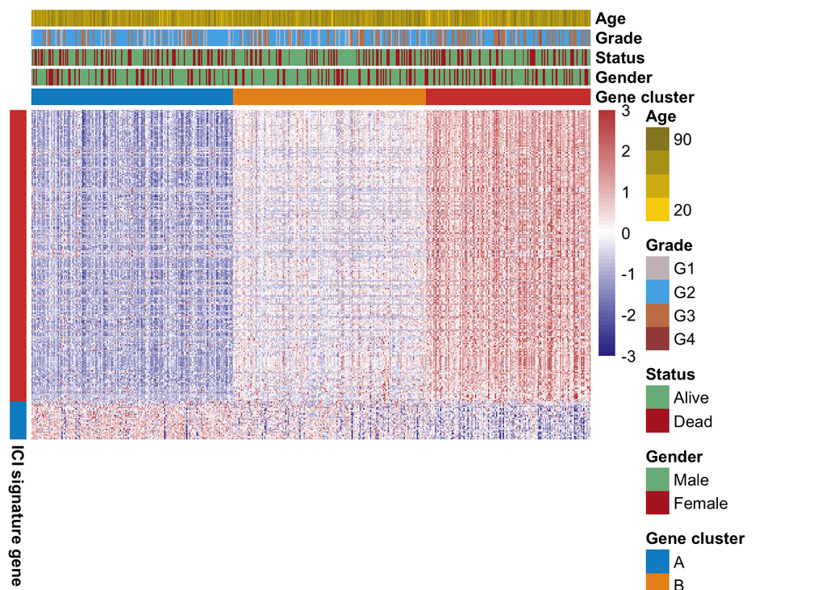

```r
annRow <- data.frame("ICI signature gene" = rep(c("A","B"), c(nrow(boruta.A), nrow(boruta.B))),
                     row.names = c(boruta.A$gene,boruta.B$gene),
                     check.names = F,
                     stringsAsFactors = F)
annColors <- list("Gene cluster" = c("A" = "#008ECB", "B" = "#EA921D", "C" = "#D14039"),
                  "Gender" = c("Male" = "#79B789", "Female" = "#B5262A"),
                  "Status" = c("Alive" = "#79B789", "Dead" = "#B5262A"),
                  "Grade" = c("G1" = "#CBBEC1", "G2" = "#53B1E7", "G3" = "#C78157", "G4" = "#A54D48"),
                  "Age" = colorRampPalette(c("#F7D202", "#96862A"))(64),
                  "ICI signature gene" = c("A" = "#D14039", "B" = "#008ECB"))
plotdata <- indata[rownames(annRow), rownames(annCol)]
plotdata[plotdata > 3] <- 3 # 截断极端值 # Truncate extreme values
plotdata[plotdata < -3] <- -3 # 截断极端值 # Truncate extreme values
pheatmap(plotdata,
         cluster_rows = F,
         cluster_cols = F,
         show_rownames = F,
         show_colnames = F,
         annotation_row = annRow,
         annotation_col = annCol,
         annotation_colors = annColors,
         color = colorRampPalette(c("#343493", "white", "#C24A45"))(64))
```

```r
dev.copy2pdf(file = "heatmap_dimension_reduced.pdf", width = 10, height = 8) # 保存图像 # Save the image
```

把这里的`heatmap_dimension_reduced.pdf`跟FigureYa201ClusterCorrelation的`ClusterCorrelation.pdf`对比一下，看看降维前后的效果。

Compare the ‘heatmap_dimension_reduced.pdf’ here with the ‘ClusterCorrelation.pdf’ of FigureYa201ClusterCorrelation to see the effect before and after dimensionality reduction.

## 8 联合主成分分析第一主成分计算ICI得分 Combined principal component analysis (PCA) first principal component to calculate the ICI score

```r
# 在“输入文件”那里，已经做过z-score处理，因此这里不再进行标准化
# In the "Input File" section, the z-score has already been processed, so it is no longer normalized here
expr.A <- indata[boruta.A$gene,rownames(annCol)]
pca.A <- prcomp(t(expr.A), scale = F, center = F) # 如果数据没有标准化，这里都要设置为TRUE # If the data is not normalized, it must be set to TRUE
pca1.A <- pca.A$x[,1] # 取出第一主成分 # Remove the first principal component

expr.B <- indata[boruta.B$gene,rownames(annCol)]
pca.B <- prcomp(t(expr.B), scale = F, center = F) #如果数据没有标准化，这里都要设置为TRUE # If the data is not normalized, it should be set to TRUE
pca1.B <- pca.B$x[,1] # 取出第一主成分 # Remove the first principal component

ICI.score <- pca1.A - pca1.B # 主成份相减得到ICI得分 # Subtract the principal components to get the ICI score
ICI.outtab <- data.frame(samID = rownames(annCol),
                         pca1.A = pca1.A[rownames(annCol)],
                         pca1.B = pca1.B[rownames(annCol)],
                         ICI.score = ICI.score[rownames(annCol)],
                         subtype = annCol$`Gene cluster`,
                         stringsAsFactors = F)
# 输出到文件
# Output to file
write.table(ICI.outtab,"output_ICI_score.txt",sep = "\t",row.names = F,col.names = T,quote = F)
```

## 9 画图对比ABC三类的ICI score Draw and compare the ICI scores of the three types of ABC

参考FigureYa162boxViolin的画法

Refer to FigureYa162boxViolin’s drawing method

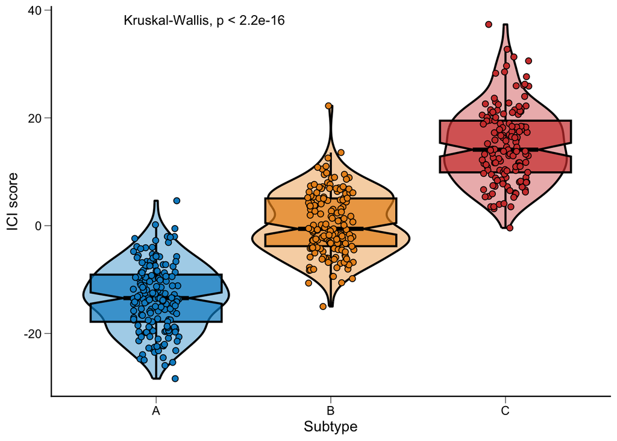

```r
ggplot(data = ICI.outtab,aes(x = subtype, y = ICI.score, fill = subtype))+
  scale_fill_manual(values = c("#008ECB", "#EA921D", "#D14039")) +
  geom_violin(alpha=0.4, position = position_dodge(width = .75),
              size=0.8, color="black") + # 边框线黑色 # The border line is black
  geom_boxplot(notch = TRUE, outlier.size = -1,
               color="black", lwd=0.8, alpha = 0.7)+ # 背景色透明化 # The background color is transparent
  geom_point(shape = 21, size=2,
             position = position_jitterdodge(),
             color="black", alpha=1)+ # 边框线黑色 # The border line is black
  theme_classic() +
  ylab(expression("ICI score")) +
  xlab("Subtype")  +
  theme(axis.ticks = element_line(size=0.2,color="black"),
    axis.ticks.length = unit(0.2,"cm"),
    legend.position = "none",
    axis.title = element_text(size = 12),
    axis.text = element_text(size = 10)) +
  stat_compare_means(method = "kruskal.test", label.y = max(ICI.score))
```

```r
ggsave(filename = "ICI_score.pdf", width = 5, height = 5)
```